# Measures of Influence

It is possible for a single observation to have a great influence on the results of a regression. It is, therefore, important to detect influential observations to take them into consideration when interpreting results.

## Cook’s D Bar Plot

Cook’s distance was introduced in 1977 by American statician R Dennis Cook. It depends on both the residual and leverage. The steps to compute it are: * delete observations one at a time * refit the regression model on the remaining observations * examine how much the fitted values changed after the observation was deleted

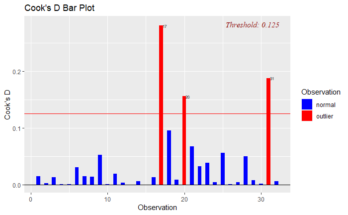

```r
model <- lm(mpg ~ disp + hp + wt + qsec, data = mtcars)
ols_plot_cooksd_bar(model)
```

## Cook’s D Chart

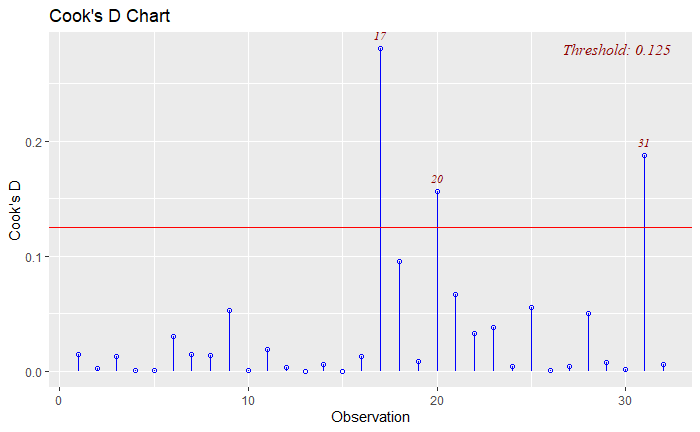

```r
model <- lm(mpg ~ disp + hp + wt + qsec, data = mtcars)
ols_plot_cooksd_chart(model)
```

## DFBETAs Panel

DFBETA measures the difference in each parameter estimate with and without the influential point. There is a DFBETA for each data point.

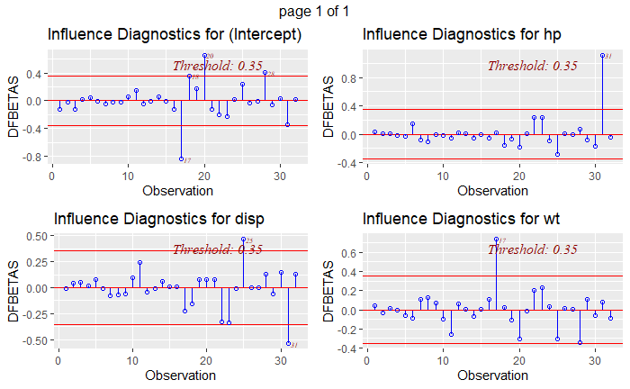

```r
model <- lm(mpg ~ disp + hp + wt, data = mtcars)
ols_plot_dfbetas(model)
```

## DFFITS Plot

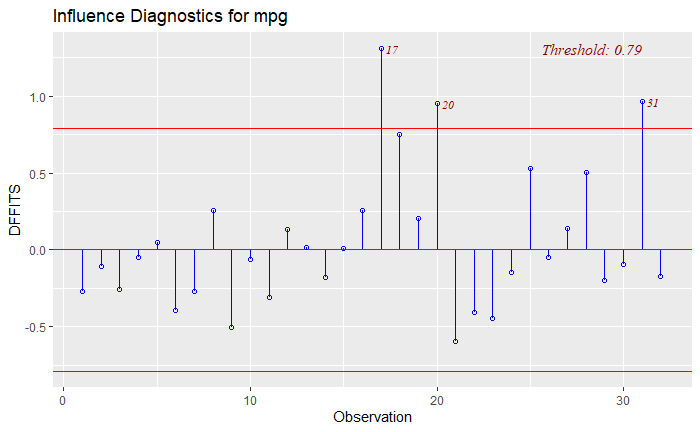

```r
model <- lm(mpg ~ disp + hp + wt + qsec, data = mtcars)
ols_plot_dffits(model)
```

## Studentized Residual Plot

Studentized deleted residuals is the deleted residual divided by its estimated standard deviation. If an observation has a studentized deleted residual larger than 3 (absolute value) we call it an outlier.

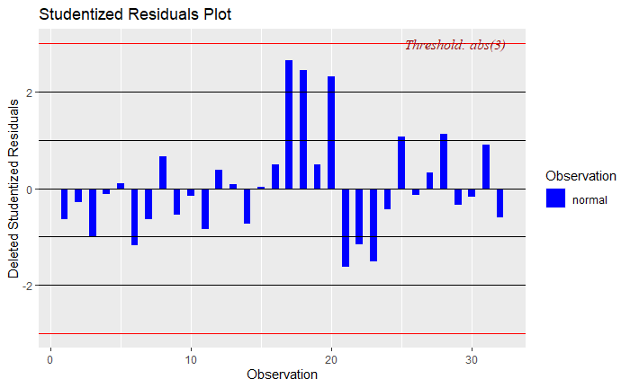

```r
model <- lm(mpg ~ disp + hp + wt + qsec, data = mtcars)
ols_plot_resid_stud(model)
```

## Standardized Residual Chart

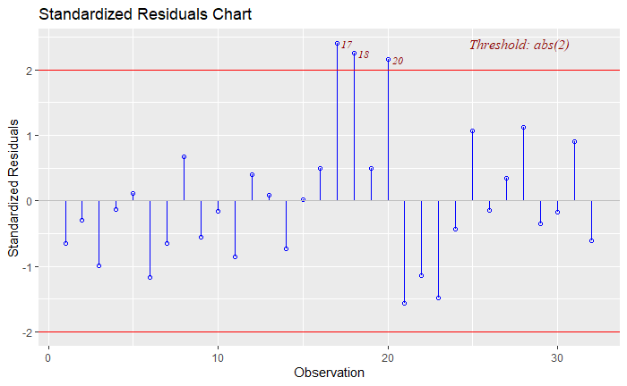

```r
model <- lm(mpg ~ disp + hp + wt + qsec, data = mtcars)
ols_plot_resid_stand(model)
```

## Studentized Residuals vs Leverage Plot

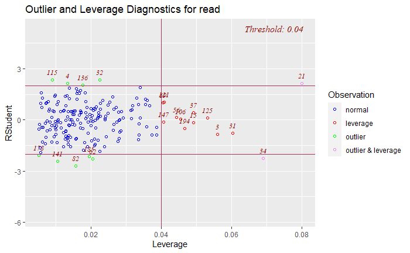

```r
model <- lm(read ~ write + math + science, data = hsb)
ols_plot_resid_lev(model)
```

## Deleted Studentized Residual vs Fitted Values Plot

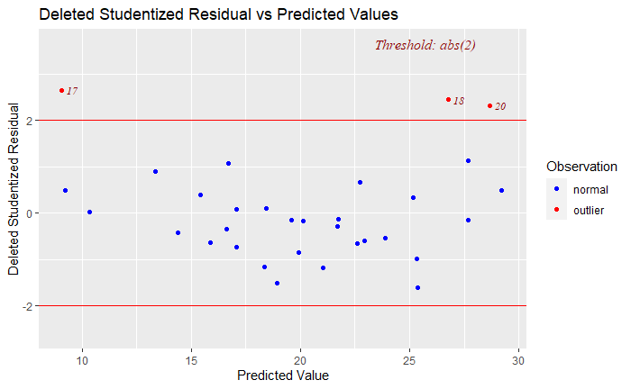

```r
model <- lm(mpg ~ disp + hp + wt + qsec, data = mtcars)
ols_plot_resid_stud_fit(model)
```

## Hadi Plot

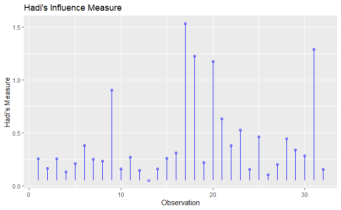

```r
model <- lm(mpg ~ disp + hp + wt + qsec, data = mtcars)
ols_plot_hadi(model)
```

## Potential Residual Plot

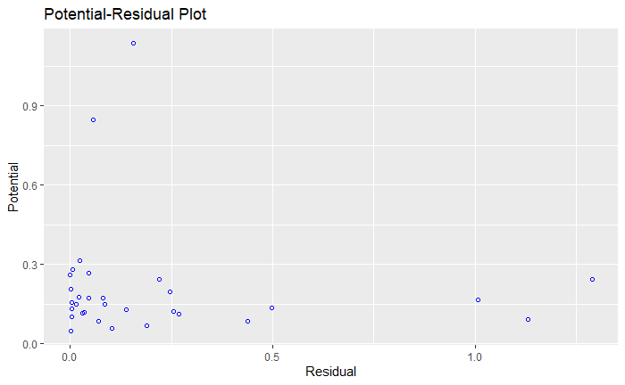

```r
model <- lm(mpg ~ disp + hp + wt + qsec, data = mtcars)
ols_plot_resid_pot(model)
```

## Reference

https://olsrr.rsquaredacademy.com/articles/influence_measures.html